# 01 - Descriptive analysis

01_descriptive_analysis.qmd

# Overview

In this document, we perform a descriptive analysis to investigate whether autotomy in *Jussara sp.* differs between leg types (I, II, III, or IV), side of the body (right or left) and populations (2002, 2009, 2011, 2012). We use generalized linear mixed models (GLMMs) to analyze the data, accounting for the repeated measures on individuals.

```r
library(here)
library(dplyr)
library(tidyr)
library(glmmTMB)
library(DHARMa)
library(emmeans)
library(ggplot2)
library(cowplot)
library(patchwork)
```

The `data_raw` dataset contains the raw data on autotomy for *Jussara sp.* collected by different collectors across four years (2002, 2009, 2011, and 2012). Each row corresponds to an individual, and the columns include information on the population (collector), leg type (r1, r2, r3, r4 for right legs and l1, l2, l3, l4 for left legs), and whether autotomy occurred (0 or 1). The data is already temporally organized and each collector is associated with a different year (TG = 2002, MC = 2009, GE = 2011 and GP = 2012).

```r
data_raw <- read.table(here("data","raw","data.tsv"), header = T, stringsAsFactors = T, sep='\t')

str(data_raw)
```

```
'data.frame':   1405 obs. of  13 variables:
 $ id        : int  1 2 3 4 5 6 7 8 9 10 ...
 $ r1        : int  0 0 0 0 0 0 0 0 0 0 ...
 $ r2        : int  0 0 0 0 0 0 0 0 0 0 ...
 $ r3        : int  0 0 0 0 0 0 0 0 0 0 ...
 $ r4        : int  0 0 0 0 0 0 0 0 0 0 ...
 $ l1        : int  0 0 0 0 0 0 0 0 0 0 ...
 $ l2        : int  0 0 0 0 0 0 0 0 0 0 ...
 $ l3        : int  0 0 0 0 0 0 0 0 0 0 ...
 $ l4        : int  0 0 0 0 0 0 0 0 0 0 ...
 $ right     : int  0 0 0 0 0 0 0 0 0 0 ...
 $ left      : int  0 0 0 0 0 0 0 0 0 0 ...
 $ total     : int  0 0 0 0 0 0 0 0 0 0 ...
 $ population: Factor w/ 4 levels "GE","GP","MC",..: 4 4 4 4 4 4 4 4 4 4 ...
```

```r
# reorder the levels of the population factor to ensure they are in the correct temporal order
data_raw <- data_raw %>%
  mutate(population = factor(population, levels = c("TG", "MC", "GE", "GP")))

# creating a presence/absence of autotomy column
data_raw$autotomized <- ifelse(data_raw$total >= 1, 1, 0)

# changing the names of the population to the year they've been collected
data_raw <- data_raw %>%
  mutate(population = recode(population,
    "TG" = "2002",
    "MC" = "2009",
    "GE" = "2011",
    "GP" = "2012"
  ))
```

```r
df_long <- data_raw[, -c(10, 11, 12,14)] %>%
  pivot_longer(cols = r1:l4,
               names_to = "leg_id",
               values_to = "autotomy") %>%
  mutate(
    side = factor(ifelse(grepl("^r", leg_id), "right", "left"),
                  levels = c("right", "left")),
    leg = factor(gsub("[rl]", "", leg_id), levels = c("1", "2", "3", "4")),
    leg_id = factor(leg_id, levels = c("r1", "r2", "r3", "r4", "l1", "l2", "l3", "l4"))
  )

str(df_long)
```

```
tibble [11,240 × 6] (S3: tbl_df/tbl/data.frame)
 $ id        : int [1:11240] 1 1 1 1 1 1 1 1 2 2 ...
 $ population: Factor w/ 4 levels "2002","2009",..: 1 1 1 1 1 1 1 1 1 1 ...
 $ leg_id    : Factor w/ 8 levels "r1","r2","r3",..: 1 2 3 4 5 6 7 8 1 2 ...
 $ autotomy  : int [1:11240] 0 0 0 0 0 0 0 0 0 0 ...
 $ side      : Factor w/ 2 levels "right","left": 1 1 1 1 2 2 2 2 1 1 ...
 $ leg       : Factor w/ 4 levels "1","2","3","4": 1 2 3 4 1 2 3 4 1 2 ...
```

```r
summary(df_long[,2:ncol(df_long)])
```

```
 population      leg_id        autotomy          side      leg
 2002:3040   r1     :1405   Min.   :0.00000   right:5620   1:2810
 2009:3880   r2     :1405   1st Qu.:0.00000   left :5620   2:2810
 2011:1664   r3     :1405   Median :0.00000                3:2810
 2012:2656   r4     :1405   Mean   :0.07447                4:2810
             l1     :1405   3rd Qu.:0.00000
             l2     :1405   Max.   :1.00000
             (Other):2810
```

```r
ggsave(here("outputs","figures","Fig_2.png"), plot = Fig2, width = 9, height = 12)
```

[output not shown]

# GLMMs for autotomy

We fitted a series of generalized linear mixed models (GLMMs) to evaluate whether the probability of autotomy varies across leg identity, body side, and population, while accounting for repeated measurements within individuals. All models included a random intercept for individual identity (id), which captures among-individual heterogeneity and the non-independence of the eight legs measured per individual.

We adopted a hierarchical modeling strategy, starting from a null model with only the random effect of individual, and progressively adding fixed effects of leg type, side, and population, as well as their interactions. Model comparisons were conducted using likelihood ratio tests and AIC, allowing us to assess whether autotomy probabilities vary across these factors and whether interaction terms are supported by the data.

Importantly, these models are not intended to directly test our focal biological hypotheses. Instead, they are used to identify whether baseline probabilities of autotomy differ across legs, sides, or populations. This step is critical to inform the structure of subsequent permutation analyses, in which we test whether individuals avoid losing functionally redundant legs (same type) or impair locomotion (same side). Specifically, if autotomy probabilities differ across legs or sides, permutation procedures must preserve this structure to avoid biased inference.

We initially considered zero-inflated models to account for the large proportion of zeros in the data. However, following the recommendations in the DHARMa documentation (Hartig 2024), we did not include zero-inflated models in our final model set. For Bernoulli (0/1) data, an excess of zeros is expected when the underlying probability of success is low, and does not by itself indicate zero inflation. Moreover, zero-inflated binomial models can lead to overfitting and convergence issues when there is no clear biological mechanism generating structural zeros. In our system, all legs are in principle capable of autotomizing, and the observed zeros most likely reflect the natural rarity of the event rather than a separate zero-generating process.

Model diagnostics were performed using the DHARMa package. However, interpretation of residual diagnostics requires caution for Bernoulli data. Because each observation represents a single trial, the variance is fully determined by the mean, and heterogeneity in underlying probabilities may not manifest as overdispersion or visible residual patterns. Consequently, standard diagnostic plots may suggest an adequate fit even when relevant predictors are missing.

To improve sensitivity to structured model misfit, we examined grouped residuals using biologically meaningful variables, including individual identity (id), leg type (leg), side (side), and population. Following DHARMa guidelines, grouping residuals by variables that may correlate with model error can reveal hidden structure, such as unmodeled heterogeneity or missing predictors. In this context, evidence of dispersion or non-uniformity after grouping is interpreted as an indication of structured model misfit, rather than as classical overdispersion.

Overall, model adequacy was assessed based on convergence, stability of parameter estimates, and consistency between model structure and biological expectations, rather than relying solely on residual diagnostics.

## Null models

The null model assumes a constant probability of autotomy across all legs and populations, while accounting for repeated measures via a random intercept for individual identity (`id`).

Although standard diagnostics did not indicate lack of fit, grouped residuals revealed strong deviations when structured by leg and population, but not by individual identity. This indicates substantial heterogeneity in autotomy probabilities across legs and populations that is not captured by a constant-probability model, while confirming that among-individual variation is adequately modeled by the random effect.

These results justify the inclusion of leg and population as fixed effects in subsequent models.

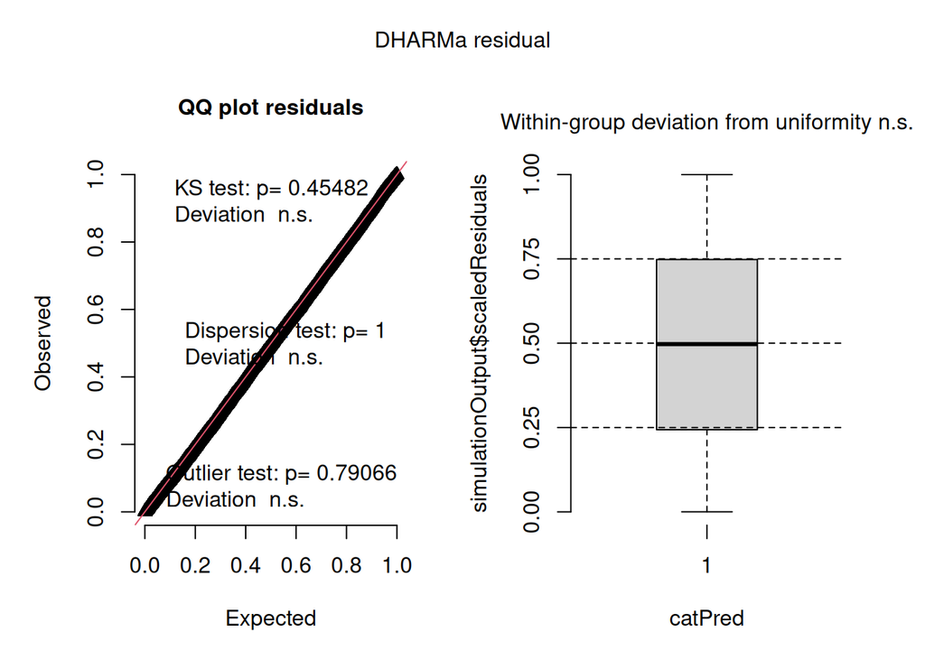

```r
m0 <- glmmTMB(autotomy ~ 1 + (1|id),
              family = binomial(link = "logit"),
              data = df_long)

m0sim <- simulateResiduals(m0, plot = T)
```

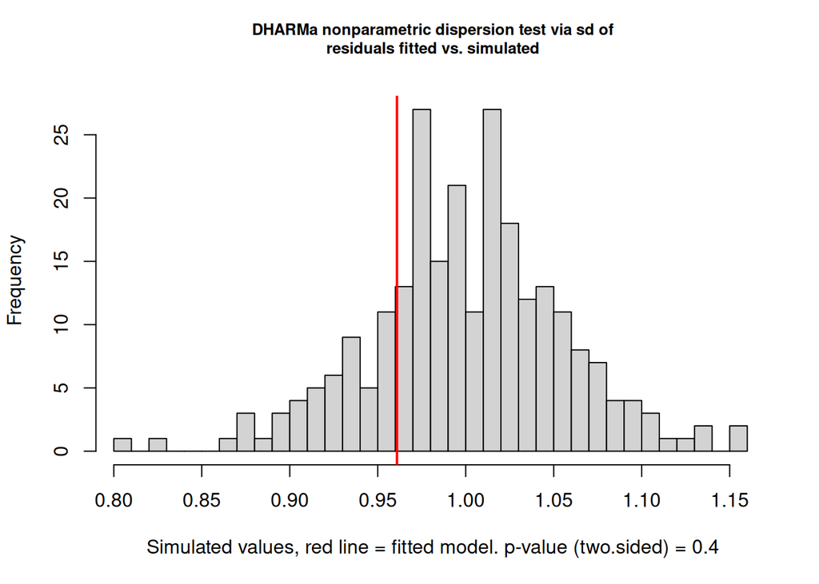

```
    DHARMa nonparametric dispersion test via sd of residuals fitted vs.
    simulated

data:  simulationOutput
dispersion = 0.9609, p-value = 0.4
alternative hypothesis: two.sided
```

```r
# group by individual
testDispersion(recalculateResiduals(m0sim, group = df_long$id))
```

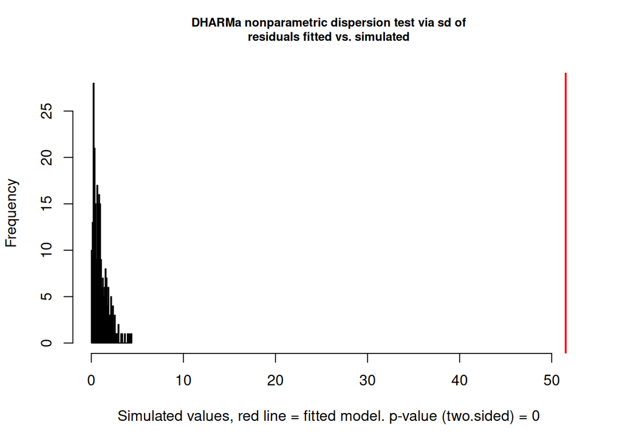

```
    DHARMa nonparametric dispersion test via sd of residuals fitted vs.
    simulated

data:  simulationOutput
dispersion = 52.012, p-value < 2.2e-16
alternative hypothesis: two.sided
```

```r
# group by leg
testDispersion(recalculateResiduals(m0sim, group = df_long$leg))
```

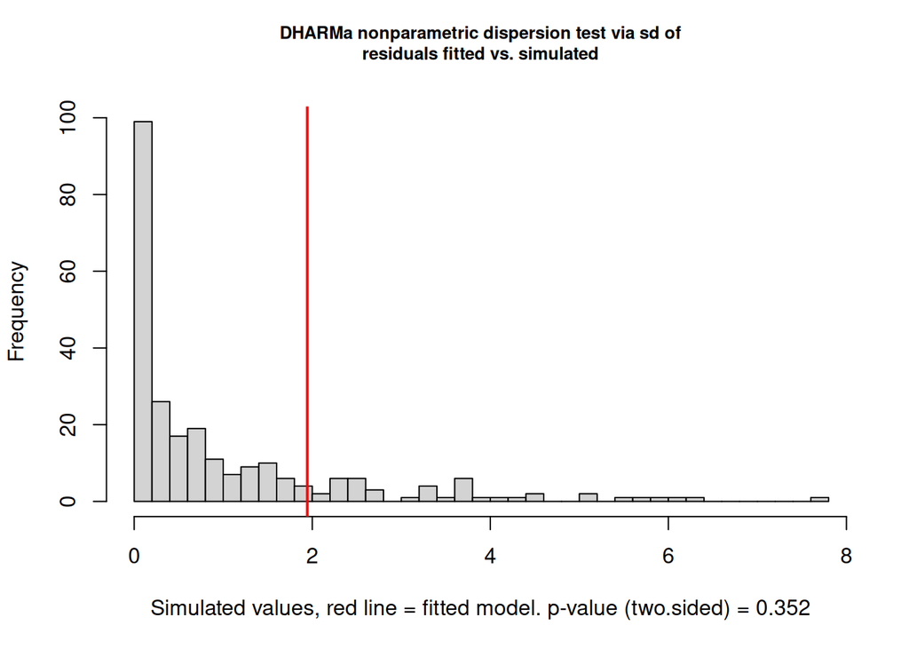

```
    DHARMa nonparametric dispersion test via sd of residuals fitted vs.
    simulated

data:  simulationOutput
dispersion = 1.9459, p-value = 0.352
alternative hypothesis: two.sided
```

```r
# group by side
testDispersion(recalculateResiduals(m0sim, group = df_long$side))
```

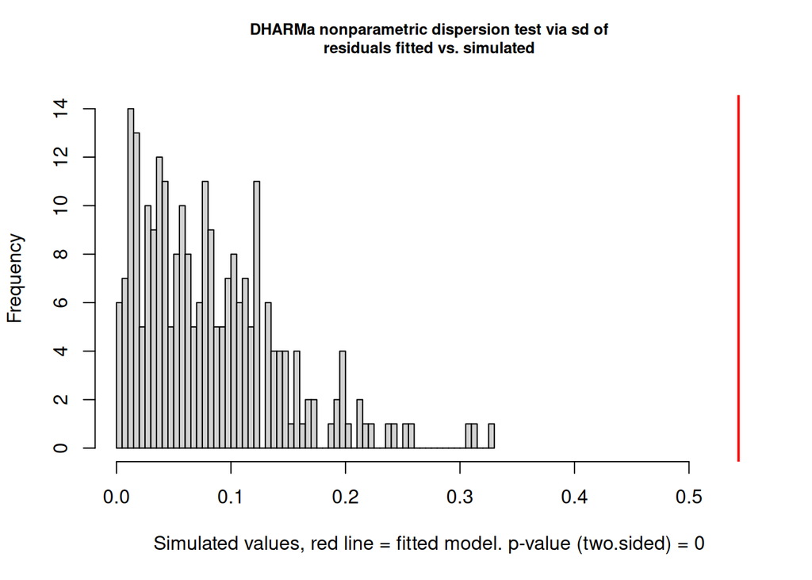

```
    DHARMa nonparametric dispersion test via sd of residuals fitted vs.
    simulated

data:  simulationOutput
dispersion = 6.6375, p-value < 2.2e-16
alternative hypothesis: two.sided
```

```r
# group by population
testDispersion(recalculateResiduals(m0sim, group = df_long$population))
```

## No interaction

We fitted a model including side, leg, and population as fixed effects, and a random intercept for individual identity (`id`) to account for repeated measures. By excluding interaction terms, this model assumes that the effects of `leg`, `side`, and `population` are additive.

Population was treated as a fixed effect due to the small number of levels (four), allowing direct estimation of differences in autotomy probability among collectors.

Including leg and population as fixed effects removed the structured deviations observed in the null model. Grouped residual diagnostics did not reveal significant dispersion when structured by leg, population, side, or individual identity, indicating that the additive model adequately captures the main sources of variation in autotomy probability.

These results indicate that variation in autotomy probability is primarily structured by leg identity and population, with no evidence of additional unmodeled heterogeneity at this level of complexity.

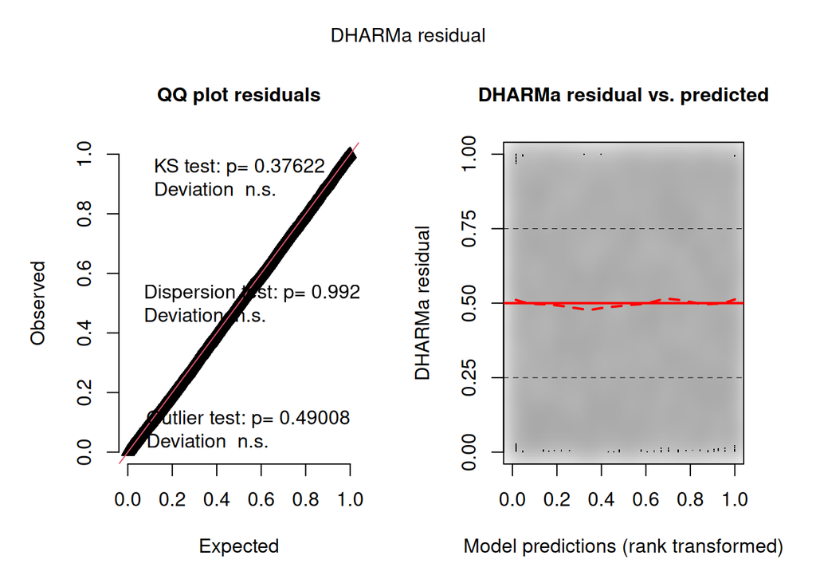

```r
m1 <- glmmTMB(autotomy ~ side + leg + population + (1|id),
              family = binomial(link = "logit"),
              data = df_long)

m1sim <- simulateResiduals(m1, plot = T)
```

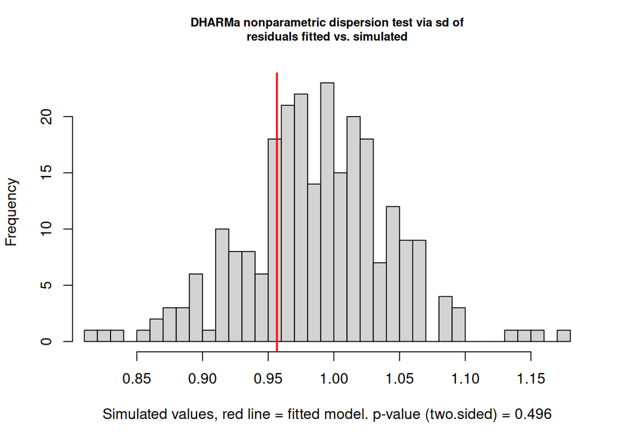

```
    DHARMa nonparametric dispersion test via sd of residuals fitted vs.
    simulated

data:  simulationOutput
dispersion = 0.96924, p-value = 0.496
alternative hypothesis: two.sided
```

```r
# group by individual
testDispersion(recalculateResiduals(m1sim, group = df_long$id))
```

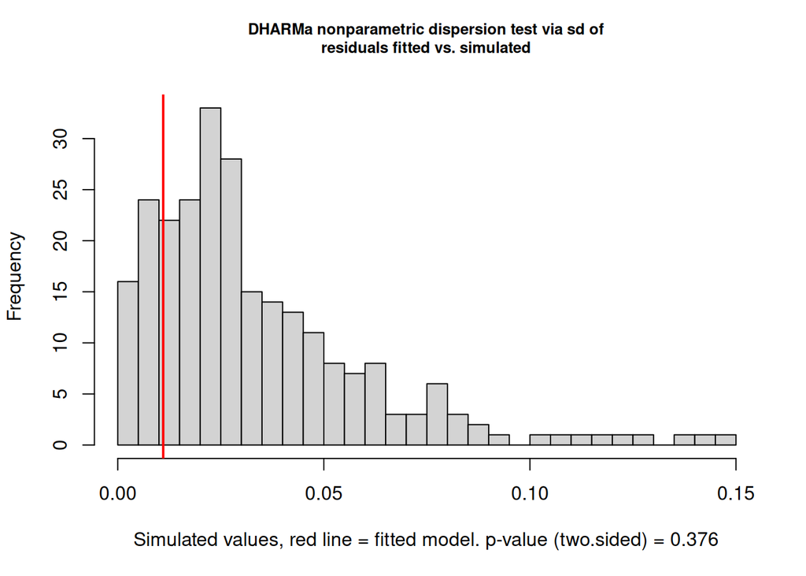

```
    DHARMa nonparametric dispersion test via sd of residuals fitted vs.
    simulated

data:  simulationOutput
dispersion = 0.33073, p-value = 0.376
alternative hypothesis: two.sided
```

```r
# group by leg
testDispersion(recalculateResiduals(m1sim, group = df_long$leg))
```

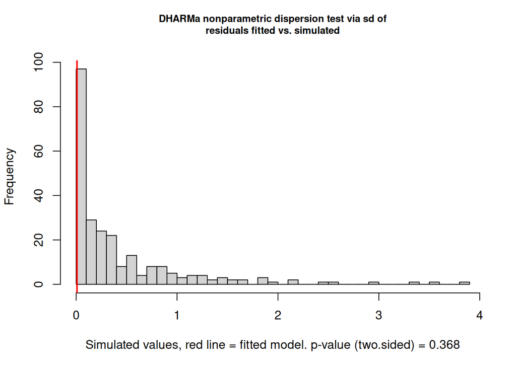

```
    DHARMa nonparametric dispersion test via sd of residuals fitted vs.
    simulated

data:  simulationOutput
dispersion = 0.018793, p-value = 0.368
alternative hypothesis: two.sided
```

```r
# group by side
testDispersion(recalculateResiduals(m1sim, group = df_long$side))
```

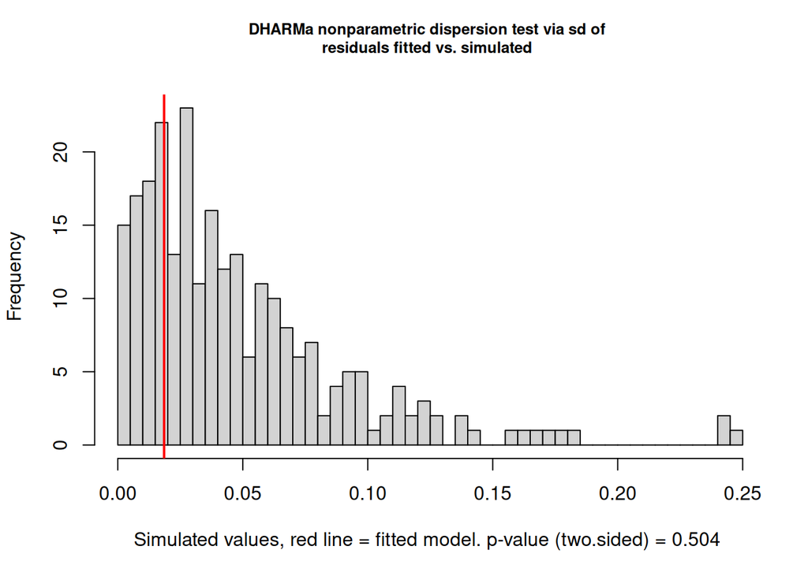

```
    DHARMa nonparametric dispersion test via sd of residuals fitted vs.
    simulated

data:  simulationOutput
dispersion = 0.38009, p-value = 0.504
alternative hypothesis: two.sided
```

```r
# group by population
testDispersion(recalculateResiduals(m1sim, group = df_long$population))
```

## Two-way interactions

We fitted a model including all two-way interactions among side, leg, and population, in addition to the random effect of individual identity (id).

Including interaction terms did not alter the residual diagnostic patterns observed for the additive model. Grouped residuals did not reveal significant dispersion when structured by leg, population, side, or individual identity, indicating that the interaction model does not capture additional structured variation beyond that already explained by the additive effects.

These results suggest that the main sources of variation in autotomy probability are adequately described by additive effects of leg identity and population, with no strong evidence for additional interaction structure at this level.

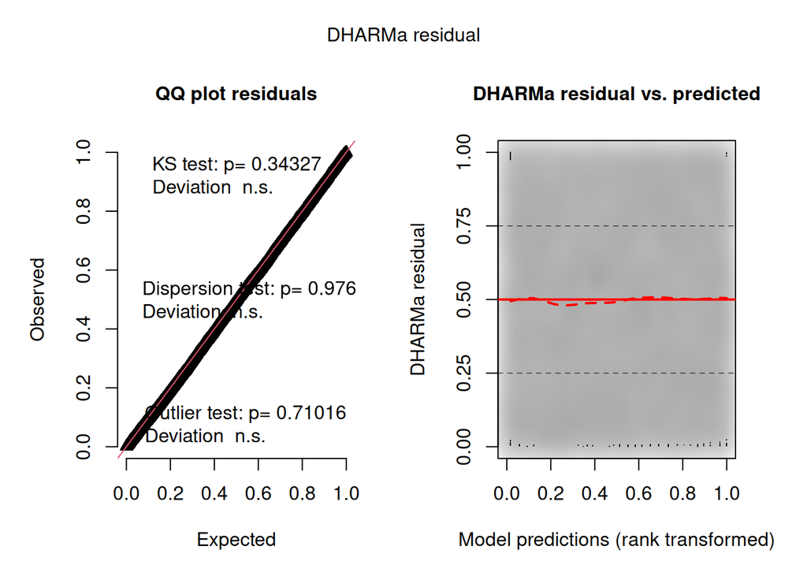

```r
m2 <- glmmTMB(autotomy ~ (side + leg + population)^2 + (1|id),
              family = binomial(link = "logit"),
              data = df_long)

m2sim <- simulateResiduals(m2, plot = T)
```

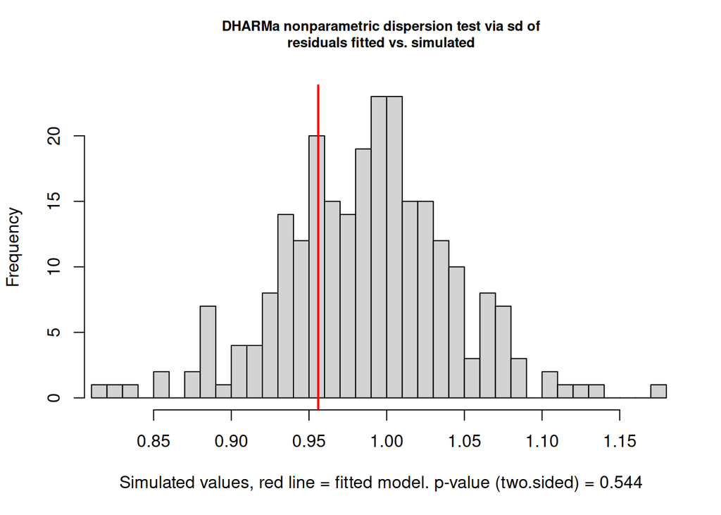

```
    DHARMa nonparametric dispersion test via sd of residuals fitted vs.
    simulated

data:  simulationOutput
dispersion = 0.96836, p-value = 0.544
alternative hypothesis: two.sided
```

```r
# group by individual
testDispersion(recalculateResiduals(m2sim, group = df_long$id))
```

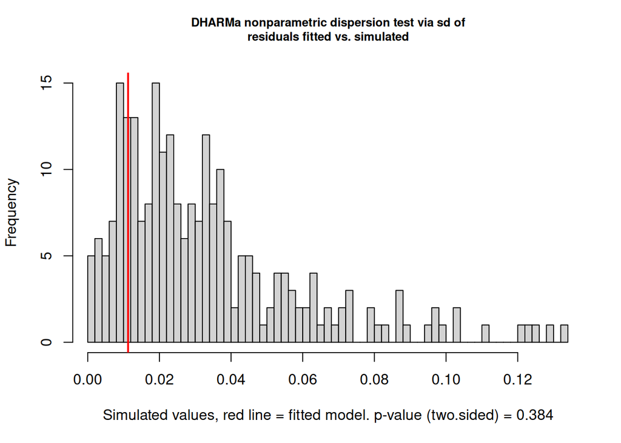

```
    DHARMa nonparametric dispersion test via sd of residuals fitted vs.
    simulated

data:  simulationOutput
dispersion = 0.3392, p-value = 0.384
alternative hypothesis: two.sided
```

```r
# group by leg
testDispersion(recalculateResiduals(m2sim, group = df_long$leg))
```

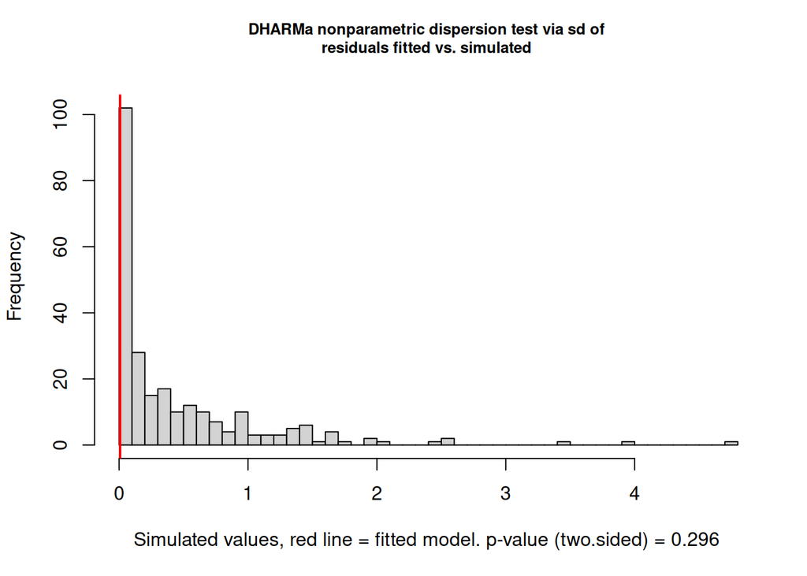

```
    DHARMa nonparametric dispersion test via sd of residuals fitted vs.
    simulated

data:  simulationOutput
dispersion = 0.016992, p-value = 0.296
alternative hypothesis: two.sided
```

```r
# group by side
testDispersion(recalculateResiduals(m2sim, group = df_long$side))
```

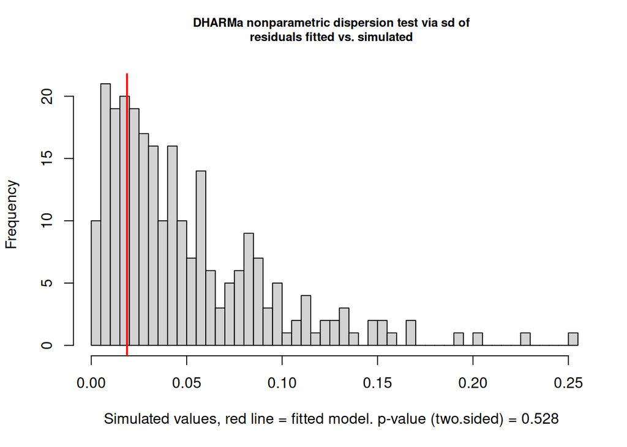

```
    DHARMa nonparametric dispersion test via sd of residuals fitted vs.
    simulated

data:  simulationOutput
dispersion = 0.3827, p-value = 0.528
alternative hypothesis: two.sided
```

```r
# group by population
testDispersion(recalculateResiduals(m2sim, group = df_long$population))
```

## Three-way interactions

We fitted a model including all two-way and three-way interactions among side, leg, and population.

As with the additive and two-way interaction models, grouped residual diagnostics did not reveal significant dispersion when structured by leg, population, side, or individual identity. Thus, including higher-order interactions did not improve model adequacy or reveal additional structured variation.

These results indicate that the main sources of variation in autotomy probability are already captured by additive effects of leg identity and population, with no evidence supporting more complex interaction structure.

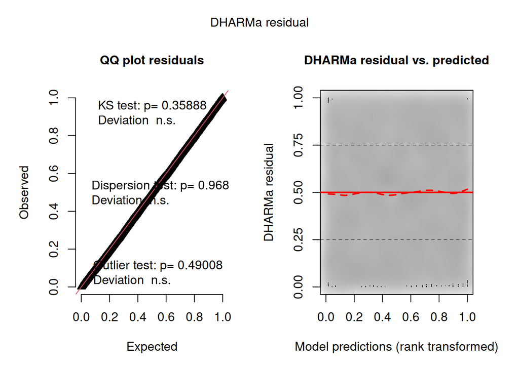

```r
m3 <- glmmTMB(autotomy ~ side * leg * population + (1|id),
              family = binomial(link = "logit"),
              data = df_long)

m3sim <- simulateResiduals(m3, plot = T)
```

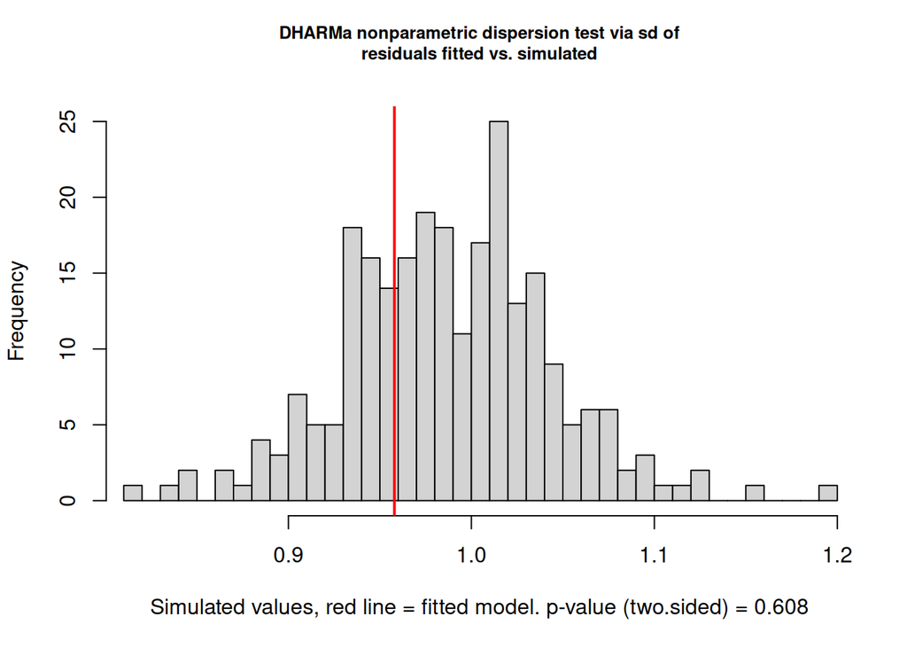

```
    DHARMa nonparametric dispersion test via sd of residuals fitted vs.
    simulated

data:  simulationOutput
dispersion = 0.97045, p-value = 0.608
alternative hypothesis: two.sided
```

```r
# group by individual
testDispersion(recalculateResiduals(m3sim, group = df_long$id))
```

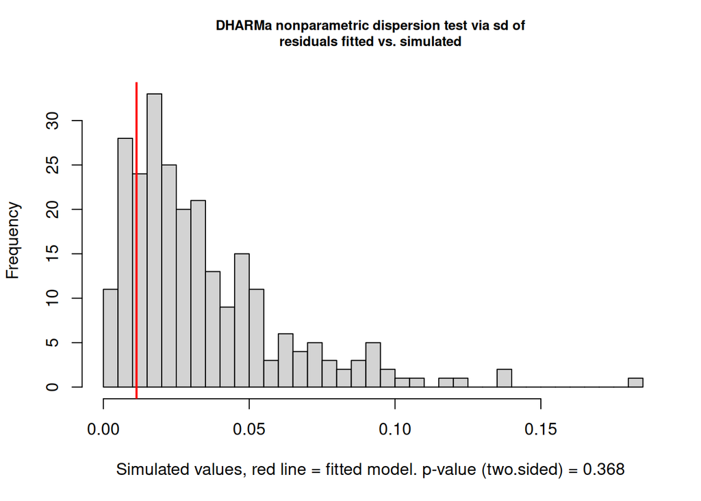

```
    DHARMa nonparametric dispersion test via sd of residuals fitted vs.
    simulated

data:  simulationOutput
dispersion = 0.33643, p-value = 0.368
alternative hypothesis: two.sided
```

```r
# group by leg
testDispersion(recalculateResiduals(m3sim, group = df_long$leg))
```

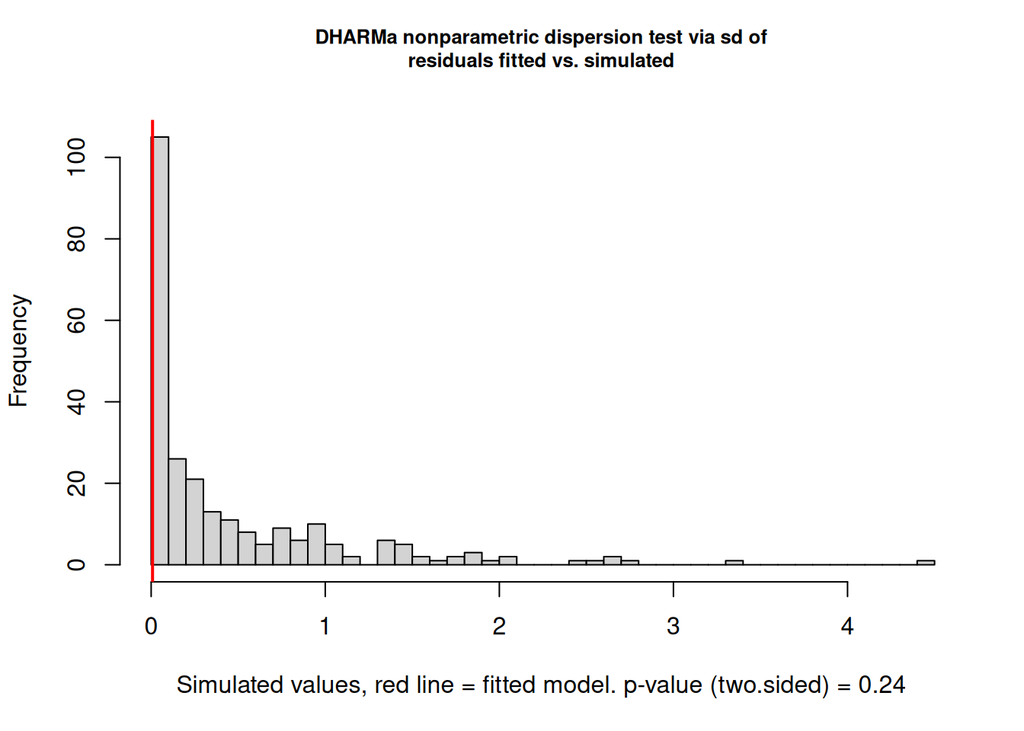

```
    DHARMa nonparametric dispersion test via sd of residuals fitted vs.
    simulated

data:  simulationOutput
dispersion = 0.017265, p-value = 0.24
alternative hypothesis: two.sided
```

```r
# group by side
testDispersion(recalculateResiduals(m3sim, group = df_long$side))
```

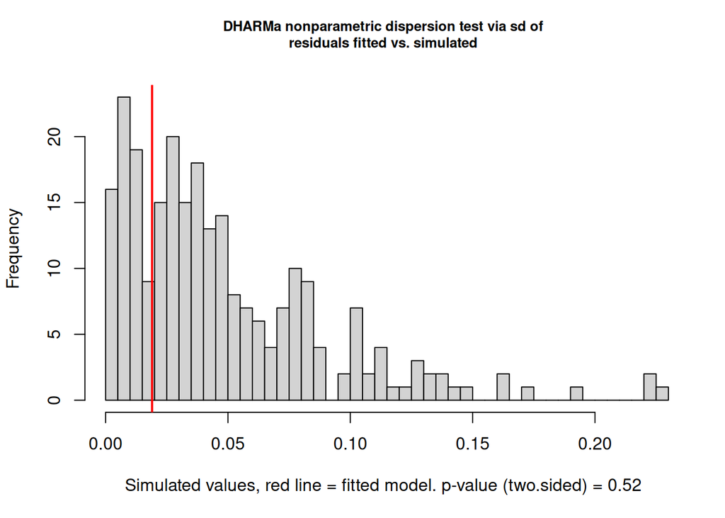

```
    DHARMa nonparametric dispersion test via sd of residuals fitted vs.
    simulated

data:  simulationOutput
dispersion = 0.39195, p-value = 0.52
alternative hypothesis: two.sided
```

```r
# group by population
testDispersion(recalculateResiduals(m3sim, group = df_long$population))
```

## Model comparison

Model comparison strongly supported the inclusion of fixed effects over the null model, with the additive model (including leg, side, and population) providing a substantially better fit than the null model. However, adding two-way or three-way interaction terms did not improve model fit, indicating that higher-order interactions are not supported by the data.

To assess the contribution of individual predictors, we compared the additive model to reduced models excluding each fixed effect. Leg identity and population both had strong effects on autotomy probability, whereas removing side did not significantly reduce model fit.

These results indicate that variation in autotomy probability is primarily structured by leg identity and population, with no evidence for strong asymmetry between left and right sides or for higher-order interaction effects.

```r
anova(m0, m1, m2, m3)
```

```
Data: df_long
Models:
m0: autotomy ~ 1 + (1 | id), zi=~0, disp=~1
m1: autotomy ~ side + leg + population + (1 | id), zi=~0, disp=~1
m2: autotomy ~ (side + leg + population)^2 + (1 | id), zi=~0, disp=~1
m3: autotomy ~ side * leg * population + (1 | id), zi=~0, disp=~1
   Df    AIC    BIC  logLik deviance    Chisq Chi Df Pr(>Chisq)
m0  2 5944.5 5959.1 -2970.2   5940.5
m1  9 5776.3 5842.2 -2879.2   5758.3 182.1865      7     <2e-16 ***
m2 24 5793.3 5969.2 -2872.7   5745.3  12.9865     15     0.6033
m3 33 5804.0 6045.8 -2869.0   5738.0   7.3604      9     0.5996
---
Signif. codes:  0 '***' 0.001 '**' 0.01 '*' 0.05 '.' 0.1 ' ' 1
```

```r
drop1(m1, test = "Chisq")
```

```
Single term deletions

Model:
autotomy ~ side + leg + population + (1 | id)
           Df    AIC     LRT  Pr(>Chi)
<none>        5776.3
side        1 5776.6   2.266 0.1322395
leg         3 5931.5 161.207 < 2.2e-16 ***
population  3 5789.1  18.782 0.0003033 ***
---
Signif. codes:  0 '***' 0.001 '**' 0.01 '*' 0.05 '.' 0.1 ' ' 1
```

## Final model

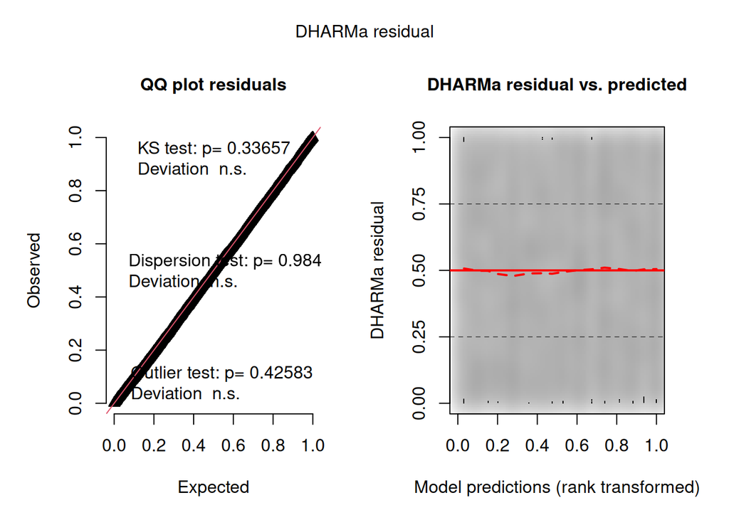

```
Object of Class DHARMa with simulated residuals based on 250 simulations with refit = FALSE . See ?DHARMa::simulateResiduals for help.

Scaled residual values: 0.2253379 0.2651702 0.6040199 0.09020382 0.7393339 0.2278479 0.8720758 0.6401489 0.2953265 0.5669027 0.8116418 0.813767 0.08149975 0.08466035 0.7264081 0.09995816 0.4955491 0.5575889 0.8271743 0.2597612 ...
```

```r
m_final <- glmmTMB(autotomy ~ leg + population + (1|id),
                   family = binomial,
                   data = df_long)

simulateResiduals(m_final, plot = T)
```

```r
summary(m_final)
```

```
 Family: binomial  ( logit )
Formula:          autotomy ~ leg + population + (1 | id)
Data: df_long

      AIC       BIC    logLik -2*log(L)  df.resid
   5776.6    5835.2   -2880.3    5760.6     11232

Random effects:

Conditional model:
 Groups Name        Variance Std.Dev.
 id     (Intercept) 0.3606   0.6005
Number of obs: 11240, groups:  id, 1405

Conditional model:
               Estimate Std. Error z value Pr(>|z|)
(Intercept)    -3.04219    0.11532 -26.380  < 2e-16 ***
leg2            0.88181    0.09984   8.832  < 2e-16 ***
leg3           -0.34331    0.12452  -2.757  0.00583 **
leg4            0.19448    0.11052   1.760  0.07848 .
population2009  0.29402    0.10317   2.850  0.00437 **
population2011  0.18038    0.13019   1.385  0.16592
population2012 -0.15093    0.12108  -1.247  0.21258
---
Signif. codes:  0 '***' 0.001 '**' 0.01 '*' 0.05 '.' 0.1 ' ' 1
```

# Marginal probabilities

We estimated marginal probabilities of autotomy for each combination of leg type and population using the `emmeans` package, obtaining predictions on the response scale while averaging over random effects.

Estimated probabilities revealed a consistent pattern across populations, with leg II showing the highest probability of autotomy and leg III the lowest, while legs I and IV showed intermediate values. Although overall probabilities varied among populations, the relative ranking of leg types was conserved, indicating a stable functional structure in autotomy susceptibility.

```r
emm <- emmeans(m_final, ~ leg + population, type = "response")
emm <- as.data.frame(emm)

pairs(emmeans(m_final, ~ leg, type = "response"))
```

```
 contrast    odds.ratio     SE  df null z.ratio p.value
 leg1 / leg2      0.414 0.0413 Inf    1  -8.832 <0.0001
 leg1 / leg3      1.410 0.1760 Inf    1   2.757  0.0298
 leg1 / leg4      0.823 0.0910 Inf    1  -1.760  0.2930
 leg2 / leg3      3.405 0.3770 Inf    1  11.053 <0.0001
 leg2 / leg4      1.988 0.1880 Inf    1   7.258 <0.0001
 leg3 / leg4      0.584 0.0704 Inf    1  -4.463 <0.0001

Results are averaged over the levels of: population
P value adjustment: tukey method for comparing a family of 4 estimates
Tests are performed on the log odds ratio scale
```

```r
pairs(emmeans(m_final, ~ population, type = "response"))
```

```
 contrast                        odds.ratio     SE  df null z.ratio p.value
 population2002 / population2009      0.745 0.0769 Inf    1  -2.850  0.0227
 population2002 / population2011      0.835 0.1090 Inf    1  -1.385  0.5085
 population2002 / population2012      1.163 0.1410 Inf    1   1.247  0.5972
 population2009 / population2011      1.120 0.1360 Inf    1   0.938  0.7842
 population2009 / population2012      1.560 0.1740 Inf    1   3.997  0.0004
 population2011 / population2012      1.393 0.1900 Inf    1   2.423  0.0729

Results are averaged over the levels of: leg
P value adjustment: tukey method for comparing a family of 4 estimates
Tests are performed on the log odds ratio scale
```

```r
ggsave(here("outputs","figures","Fig_3.png"), plot = Fig_3, width = 10, height = 7)
```

[output not shown]

The results indicate that autotomy differs across populations. We used a pairwise comparison to identify which populations differed. However, this pattern may be driven by the 2009 population having a higher number of individuals that autotomized two or more legs. Therefore, we also tested whether the proportion of individuals exhibiting autotomy differed among populations using a GLM.

```r
ma <- glm(autotomized ~ population,
         family = binomial,
         data = data_raw)

summary(ma)
```

```
Call:
glm(formula = autotomized ~ population, family = binomial, data = data_raw)

Coefficients:
               Estimate Std. Error z value Pr(>|z|)
(Intercept)     -0.3293     0.1040  -3.166  0.00154 **
population2009   0.1515     0.1383   1.095  0.27341
population2011   0.2908     0.1734   1.677  0.09346 .
population2012  -0.2009     0.1540  -1.304  0.19219
---
Signif. codes:  0 '***' 0.001 '**' 0.01 '*' 0.05 '.' 0.1 ' ' 1

(Dispersion parameter for binomial family taken to be 1)

    Null deviance: 1920.6  on 1404  degrees of freedom
Residual deviance: 1911.2  on 1401  degrees of freedom
AIC: 1919.2

Number of Fisher Scoring iterations: 4
```

```r
anova(ma, test = "Chisq")
```

```
Analysis of Deviance Table

Model: binomial, link: logit

Response: autotomized

Terms added sequentially (first to last)

           Df Deviance Resid. Df Resid. Dev Pr(>Chi)
NULL                        1404     1920.6
population  3    9.437      1401     1911.2  0.02401 *
---
Signif. codes:  0 '***' 0.001 '**' 0.01 '*' 0.05 '.' 0.1 ' ' 1
```

```r
saveRDS(emm, file = here("data","processed","marginal_autotomy_probabilities.rds"))
```